# A3-Incarceration

Phuong Hung Lai

2/25/2022

## Introduction

Using the dataset introduced by *Vera Institute of Justice* about the jails prisons in all counties of the US, we can clearly see that the distribution of convicts and criminals is significantly different between races, urban and rural. In this report, most of the analyses are used expose the discrimination between races. Moreover, the difference between urban and rural areas will also be analysed

```r
print(summary_table)
```

```
## # A tibble: 19 x 5
##     year state max_jail_state_adm ave_jail_adm total_pop
##    <int> <chr>              <dbl>        <dbl>     <dbl>
##  1  2000 TX              1295381.       218129    629518
##  2  2001 TX              1179422.       216251    641333
##  3  2002 TX              1172170.       224879    665362
##  4  2003 CA              1177304.       224986    694040
##  5  2004 TX              1357216.       253850    719877
##  6  2005 CA              1270078.       237663    736740
##  7  2006 CA              1267238.       241900    761823
##  8  2007 CA              1225867.       244800    770012
##  9  2008 CA              1263180.       249014    778201
## 10  2009 CA              1191952.       239482    772897
## 11  2010 CA              1125195.       231406    758632
## 12  2011 TX              1122238.       225860    749994
## 13  2012 CA              1102261.       223953    752998
## 14  2013 TX              1095380.       221327    759472
## 15  2014 TX              1096355.       221300    763122
## 16  2015 TX              1066915.       212032    732970
## 17  2016 TX              1095432.       208632    733127
## 18  2017 TX              1061138.       207376    740512
## 19  2018 TX              1039833.       206739    737126
```

# Summary Variables

THe following variables will help me make a sufficients analysis about the incarceration trend in the last 2 decades.

### Total jail people in last 2 decades:

```
## # A tibble: 19 x 5
##     year state max_jail_state_adm ave_jail_adm total_pop
##    <int> <chr>              <dbl>        <dbl>     <dbl>
##  1  2000 TX              1295381.       218129    629518
##  2  2001 TX              1179422.       216251    641333
##  3  2002 TX              1172170.       224879    665362
##  4  2003 CA              1177304.       224986    694040
##  5  2004 TX              1357216.       253850    719877
##  6  2005 CA              1270078.       237663    736740
##  7  2006 CA              1267238.       241900    761823
##  8  2007 CA              1225867.       244800    770012
##  9  2008 CA              1263180.       249014    778201
## 10  2009 CA              1191952.       239482    772897
## 11  2010 CA              1125195.       231406    758632
## 12  2011 TX              1122238.       225860    749994
## 13  2012 CA              1102261.       223953    752998
## 14  2013 TX              1095380.       221327    759472
## 15  2014 TX              1096355.       221300    763122
## 16  2015 TX              1066915.       212032    732970
## 17  2016 TX              1095432.       208632    733127
## 18  2017 TX              1061138.       207376    740512
## 19  2018 TX              1039833.       206739    737126
```

### State with the most jail admission every year

```
## # A tibble: 19 x 3
##     year state max_jail_state_adm
##    <int> <chr>              <dbl>
##  1  2000 TX              1295381.
##  2  2001 TX              1179422.
##  3  2002 TX              1172170.
##  4  2003 CA              1177304.
##  5  2004 TX              1357216.
##  6  2005 CA              1270078.
##  7  2006 CA              1267238.
##  8  2007 CA              1225867.
##  9  2008 CA              1263180.
## 10  2009 CA              1191952.
## 11  2010 CA              1125195.
## 12  2011 TX              1122238.
## 13  2012 CA              1102261.
## 14  2013 TX              1095380.
## 15  2014 TX              1096355.
## 16  2015 TX              1066915.
## 17  2016 TX              1095432.
## 18  2017 TX              1061138.
## 19  2018 TX              1039833.
```

### County with the most black prisoners in Washington: **Yakima County**

### County with the most prisoners in Washington: **King County**

### Incarceration rate of all races recently:

```
## # A tibble: 5 x 3
##    year Race    Rate
##   <int> <chr>  <dbl>
## 1  2018 White   498.
## 2  2018 Black  2519.
## 3  2018 Latinx  973.
## 4  2018 Aapi    447.
## 5  2018 Native 1047.
```

## Plots

### Time series

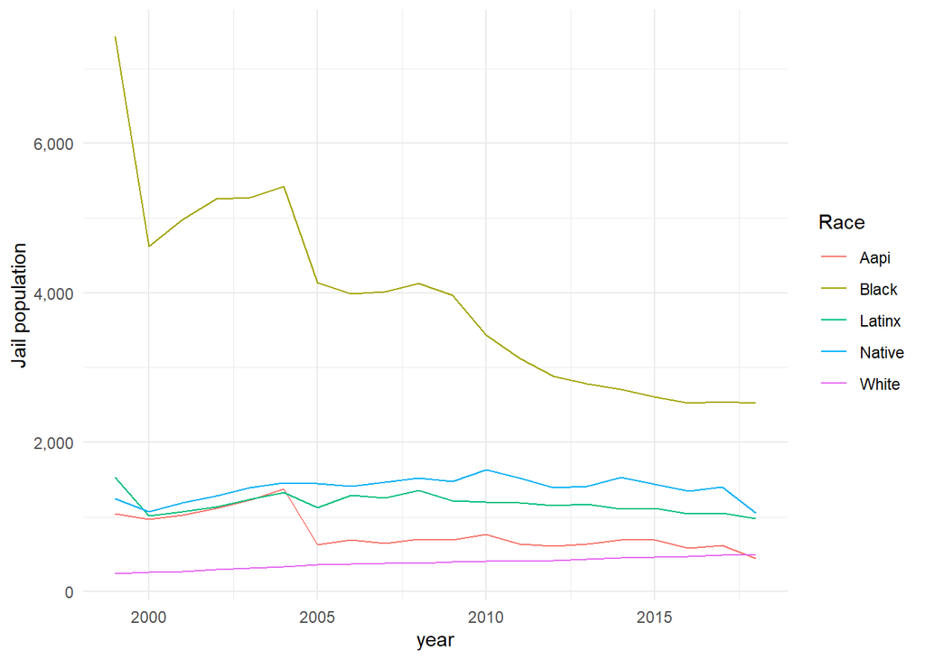